# “Feature engineering”

Paul Deveau

2017-01-05

This time, we’ll assess the capability of dealing with feature engineering.

For the first dataset, we will create a very simple relation between x,y and z: $z = x + y^2 + e$ Where e is random noise.

```r
x<-rnorm(n = rows,mean = 25, sd = 9)
y<-rnorm(n = rows,mean = 5, sd = 3)
z<-x+y**2 + runif(n = rows)
```

We save the dataset

```r
df<-data.frame(x= x,y= y,z =z)

write.table(x = df, file = "dataset2.csv",col.names = TRUE, row.names = FALSE,sep=",")
```

To check our data, we plot it:

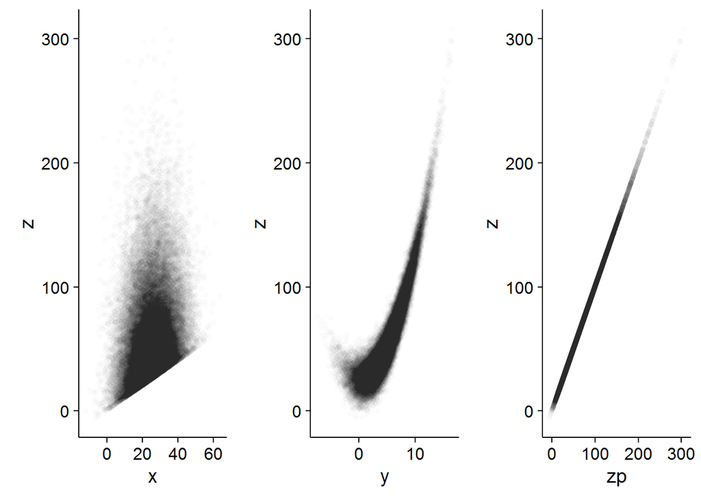

```r
df$zp<-df$x+df$y**2
xp<-ggplot(df,aes(x = x,y= z))+geom_point(alpha = I(0.01))
yp<-ggplot(df,aes(x = y,y= z))+geom_point(alpha = I(0.01))
zp<-ggplot(df,aes(x = zp,y= z))+geom_point(alpha = I(0.01))
plot_grid(xp,yp,zp,align = "v",ncol = 3)
```

We can clearly see the noise with $zp =f(z)$ , but plotting $z = f(x)$ or $z = f(y)$ is not very useful, except to shown that z is function of x and y.

When solving this kind of problem, a first sanity check is to make sure that x and y are not correlated! (I won’t check it here, maybe in the correction if I make one…)

So let’s start with correlation:

```r
cor(x = df$x, y = df$z, method = "spearman") # test rank correlation
```

```
## [1] 0.324426
```

```r
cor(x = df$y, y = df$z, method = "spearman") # test rank correlation
```

```
## [1] 0.9250681
```

```r
reg1<-lm(z ~ x+y,data = df)
reg1
```

```
##
## Call:
## lm(formula = z ~ x + y, data = df)
##
## Coefficients:
## (Intercept)            x            y
##     -15.420        1.000        9.981
```

So we can see that x and z are positively correlated, as well as x and z.

Is this model any good?

```r
cor.test(x = reg1$coefficients["x"] * df$x+ reg1$coefficients["y"]* df$y, y = df$z, method = "pearson") # test linear correlation
```

```
##
##  Pearson's product-moment correlation
##
## data:  reg1$coefficients["x"] * df$x + reg1$coefficients["y"] * df$y and df$z
## t = 547.66, df = 49998, p-value < 2.2e-16
## alternative hypothesis: true correlation is not equal to 0
## 95 percent confidence interval:
##  0.9245457 0.9270506
## sample estimates:
##       cor
## 0.9258083
```

With an $r^2$ of 0.9258083 , we can make better than that!

A good thing to estimate the coefficient of a polynom is the log/log graph (the slope when x is large gives you the maximal coefficient). Remember that semi log scales are used to find exponential laws. Here, x values can be negative, so we ofset by min(x) +1 .

```r
logdf<-df
logdf$x<-logdf$x - min(logdf$x)+1
logdf$y<-logdf$y - min(logdf$y)+1
logdf$z<-logdf$z - min(logdf$z)+1

logdf<-log(logdf)
```

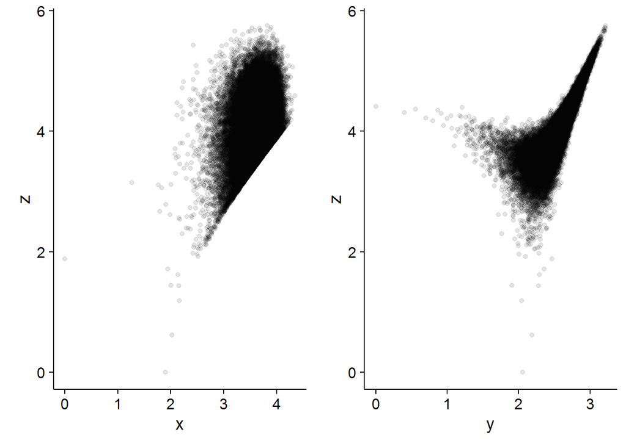

```r
xp<-ggplot(logdf,aes(x = x,y= z))+geom_point(alpha = I(0.1))
yp<-ggplot(logdf,aes(x = y,y= z))+geom_point(alpha = I(0.1))

plot_grid(xp,yp,ncol = 2)
```

Now we can see that log(z) seems to be linear with log(y) for large log(y), so we try the simplest polynom in y:

```r
df$y2<-df$y**2

reg2<-lm(z ~ x + y +y2,data = df)
cor.test(x = reg2$coefficients["x"] * df$x+ reg2$coefficients["y"]* df$y + reg2$coefficients["y2"]* df$y2, y = df$z, method = "pearson") # test linear correlation
```

```
##
##  Pearson's product-moment correlation
##
## data:  reg2$coefficients["x"] * df$x + reg2$coefficients["y"] * df$y +  and df$z    reg2$coefficients["y2"] * df$y2 and df$z
## t = 26134, df = 49998, p-value < 2.2e-16
## alternative hypothesis: true correlation is not equal to 0
## 95 percent confidence interval:
##  0.9999628 0.9999640
## sample estimates:
##       cor
## 0.9999634
```

Almost 1 correlation, so far so good, but we test on the train sample! Not good!

```r
split<-sample(1:nrow(df),size = round(nrow(df)/2))
train<-df[split,]
test<-df[-split,]
reg1<-lm(z ~ x + y +y2,data = train)
cor.test(x = reg1$coefficients["x"] * test$x+ reg1$coefficients["y"]* test$y, y = test$z, method = "pearson")
```

```
##
##  Pearson's product-moment correlation
##
## data:  reg1$coefficients["x"] * test$x + reg1$coefficients["y"] * test$y and test$z
## t = 42.086, df = 24998, p-value < 2.2e-16
## alternative hypothesis: true correlation is not equal to 0
## 95 percent confidence interval:
##  0.2456188 0.2687706
## sample estimates:
##       cor
## 0.2572316
```

```r
reg2<-lm(z ~ x + y +y2,data = train)
cor.test(x = reg2$coefficients["x"] * test$x+ reg2$coefficients["y"]* test$y + reg2$coefficients["y2"]*test$y2, y = test$z, method = "pearson")
```

```
##
##  Pearson's product-moment correlation
##
## data:  reg2$coefficients["x"] * test$x + reg2$coefficients["y"] * test$y +  and test$z    reg2$coefficients["y2"] * test$y2 and test$z
## t = 18653, df = 24998, p-value < 2.2e-16
## alternative hypothesis: true correlation is not equal to 0
## 95 percent confidence interval:
##  0.9999632 0.9999650
## sample estimates:
##       cor
## 0.9999641
```

See the difference for the case 1: the correlation is now 0.257, while our second model still is doing good!

We conclude by printing the parameters of our final model:

```r
reg2
```

```
##
## Call:
## lm(formula = z ~ x + y + y2, data = train)
##
## Coefficients:
## (Intercept)            x            y           y2
##   0.4956375    1.0002452   -0.0002948    1.0000673
```

Notice that the intercept is almost 0.5 (that is the mean of the uniform distribution across $[0;1]$ !)